```python
#import module
import numpy as np
```

# PART A

```python
# Given values
price_per_unit_usd = 1000  # The price per unit in USD
total_units = 10000        # The total quantity of phones
cost_per_unit_nok = 7000   # The cost per unit in NOK
exchange_rate = 8  # NOK/USD meaning that it needs 8 NOK per one USD(The spot exchange rate NOK/USD)


#Define a function to compute the profit margin

def calculate_profit_margin(price_per_unit_usd, total_units, cost_per_unit_nok, exchange_rate):
    # Calculate total revenues in USD
    total_revenues_usd = price_per_unit_usd * total_units

    # Convert total revenues to NOK
    total_revenues_nok = total_revenues_usd * exchange_rate

    # Calculate total costs in NOK
    total_costs_nok = cost_per_unit_nok * total_units

    # Calculate total profit in NOK
    total_profit_nok = total_revenues_nok - total_costs_nok

    # Calculate profit per unit in NOK
    profit_per_unit_nok = total_profit_nok / total_units

    # Calculate price per unit in NOK
    price_per_unit_nok = price_per_unit_usd * exchange_rate

    # Calculate the profit margin
    profit_margin = profit_per_unit_nok / price_per_unit_nok

    print(f"Total revenues in USD: {total_revenues_usd:,} USD")
    print(f"Total revenues in NOK: {total_revenues_nok:,} NOK")
    print(f"Total costs in NOK: {total_costs_nok:,} NOK")
    print(f"Total profit in NOK: {total_profit_nok:,} NOK")
    print(f"Profit per unit in NOK: {profit_per_unit_nok:,} NOK")
    print(f"Price per unit in NOK: {price_per_unit_nok:,} NOK")
    return profit_margin


# Calculate the profit margin
profit_margin = calculate_profit_margin(price_per_unit_usd, total_units, cost_per_unit_nok, exchange_rate)

# Print the profit margin
print(f"The profit margin is: {profit_margin:,.2%}")
```

```
Total revenues in USD: 10,000,000 USD
Total revenues in NOK: 80,000,000 NOK
Total costs in NOK: 70,000,000 NOK
Total profit in NOK: 10,000,000 NOK
Profit per unit in NOK: 1,000.0 NOK
Price per unit in NOK: 8,000 NOK
The profit margin is: 12.50%
```

To compute the profit margin for the following year( t+1), we need to consider the changes due to inflation, and expected exchange rate in both Norway and the US.

- Need to adjust the price in the US and the cost in Norway due to inflation. Then convert US price to NOK using expected echange rate.

```python
# Constants for year t+1
us_inflation_t1 = 1.05  # 5% inflation in the US
norway_inflation_t1 = 1.01  # 1% inflation in Norway
expected_exchange_rate_t1 = 7.6952  # Expected exchange rate NOK/USD for t+1

#Given parameter from the original
price_per_unit_usd = 1000  # The price per unit in USD
total_units = 10000        # The total quantity of phones
cost_per_unit_nok = 7000   # The cost per unit in NOK

def calculate_profit_margin_t1(price_per_unit_usd, total_units, cost_per_unit_nok, us_inflation_t1, norway_inflation_t1, expected_exchange_rate_t1):

    # Adjust prices and costs for inflation
    adjusted_price_usd = price_per_unit_usd * us_inflation_t1
    adjusted_cost_nok = cost_per_unit_nok * norway_inflation_t1

    # Convert adjusted price to NOK using the expected exchange rate
    adjusted_price_nok = adjusted_price_usd * expected_exchange_rate_t1

    # Calculate total revenues and costs in NOK for t+1
    total_revenues_nok_t1 = adjusted_price_nok * total_units
    total_costs_nok_t1 = adjusted_cost_nok * total_units

    # Calculate total profit in NOK for t+1
    total_profit_nok_t1 = total_revenues_nok_t1 - total_costs_nok_t1

    # Calculate profit per unit in NOK for t+1
    profit_per_unit_nok_t1 = total_profit_nok_t1 / total_units

    # Calculate the profit margin for t+1
    profit_margin_t1 = profit_per_unit_nok_t1 / adjusted_price_nok

    # Print each result
    print(f"Adjusted price per unit in USD for t+1: {adjusted_price_usd:,} USD")
    print(f"Adjusted cost per unit in NOK for t+1: {adjusted_cost_nok:,} NOK")
    print(f"Adjusted price per unit in NOK for t+1: {adjusted_price_nok:,} NOK")
    print(f"Total revenues in NOK for t+1: {total_revenues_nok_t1:,} NOK")
    print(f"Total costs in NOK for t+1: {total_costs_nok_t1:,} NOK")
    print(f"Total profit in NOK for t+1: {total_profit_nok_t1:,} NOK")
    print(f"Profit per unit in NOK for t+1: {profit_per_unit_nok_t1:,} NOK")

    return profit_margin_t1


# Calculate and print the profit margin for t+1
profit_margin_t1 = calculate_profit_margin_t1(
    price_per_unit_usd,
    total_units,
    cost_per_unit_nok,
    us_inflation_t1,
    norway_inflation_t1,
    expected_exchange_rate_t1
)
print(f"Profit Margin for t+1: {profit_margin_t1:.2%}")
```

```
Adjusted price per unit in USD for t+1: 1,050.0 USD
Adjusted cost per unit in NOK for t+1: 7,070.0 NOK
Adjusted price per unit in NOK for t+1: 8,079.96 NOK
Total revenues in NOK for t+1: 80,799,600.0 NOK
Total costs in NOK for t+1: 70,700,000.0 NOK
Total profit in NOK for t+1: 10,099,600.0 NOK
Profit per unit in NOK for t+1: 1,009.96 NOK
Profit Margin for t+1: 12.50%
```

# A3

We see that the profit margins in question 2A and 1A remained unchanged. There are two effects.

- Inflation impact: high inflation in the US means that the price of Norwegian company's phone in the US market will increase 5%, hence the revenue(USD)grow at 5% rate. While the cost (NOK) grow only at 1% rate due to Norwegian have lower inflation rate.
- Exchange rate Impact: The NOK appreciates againts the US dollar, from 8 to 7.6952 NOK/USD. It means hat each USD is worth fewer NOK than in 1A. For a Norwegian company that earns revenue in USD, this appreciation would be unfavorable when convert USD to NOK because you will get fewer NOK per USD.

However, with the inflation impact that the revenue in USD increase due to the inflation in the US and Revenue in NOK is impacted by the appreciation of NOK against USD. These two effects balance each other, so the profit margin maintains constant.

# A4

The financial deparment came up with such estimate of the exchange rate in year t + 1, using the concept of relative purchasing power parity(RPPP). They believe that RPPP will hold.

$ RPPP_t = S_{t-1} * \frac {1 +inflation_t} {1 + inflation_t^*} $

The results below show that the RPPP is the same as expected exchange rate. Hence ,RPPP shows that countries with higher inflation will experience currency depreciation, thus leaving the real exchange rate constant.

```python
# Given data
exchange_rate = 8.0  # NOK/USD
inflation_norway = 0.01   # Percentage
inflation_usa = 0.05     # Percentage

def calculate_rppp_exchange_rate(exchange_rate, inflation_norway, inflation_usa):
    """
    Calculate the new exchange rate based on Relative Purchasing Power Parity (RPPP).

    Parameters:
    exchange_rate (float): The current exchange rate (Home currency per Foreign currency)
    inflation_norway (float): The inflation rate in the home country (as a percentage)
    inflation_usa (float): The inflation rate in the foreign country (as a percentage)

    Returns:
    float: The new exchange rate as predicted by RPPP.
    """
    # Calculate the new exchange rate using RPPP formula
    rppp= exchange_rate * ((1 + inflation_norway) / (1 + inflation_usa))

    return rppp

# Calculate the new exchange rate
rppp = calculate_rppp_exchange_rate(exchange_rate, inflation_norway, inflation_usa)

print(f"The new exchange rate estimated by RPPP is: {rppp:.4f} NOK/USD")
```

```
The new exchange rate estimated by RPPP is: 7.6952 NOK/USD
```

# A5

We repeat the same calculations as A2 and we obtain that now the profit margin turns negative, being equal to -12.2%. This is due to the depreciation of the USD with respect to the NOK which is = 6 now instead of 7.6952. The lower NOK/USD negatively impacts the firm, which has to convert the USD into NOK at a much lower exchange rate.

```python
# Constants for year t+1
us_inflation_t1 = 1.05  # 5% inflation in the US
norway_inflation_t1 = 1.01  # 1% inflation in Norway
expected_exchange_rate_t1 = 6  # Expected exchange rate NOK/USD for t+1

#Given parameter from the original
price_per_unit_usd = 1000  # The price per unit in USD
total_units = 10000        # The total quantity of phones
cost_per_unit_nok = 7000   # The cost per unit in NOK

def calculate_profit_margin_t1(price_per_unit_usd, total_units, cost_per_unit_nok, us_inflation_t1, norway_inflation_t1, expected_exchange_rate_t1):

    # Adjust prices and costs for inflation
    adjusted_price_usd = price_per_unit_usd * us_inflation_t1
    adjusted_cost_nok = cost_per_unit_nok * norway_inflation_t1

    # Convert adjusted price to NOK using the expected exchange rate
    adjusted_price_nok = adjusted_price_usd * expected_exchange_rate_t1

    # Calculate total revenues and costs in NOK for t+1
    total_revenues_nok_t1 = adjusted_price_nok * total_units
    total_costs_nok_t1 = adjusted_cost_nok * total_units

    # Calculate total profit in NOK for t+1
    total_profit_nok_t1 = total_revenues_nok_t1 - total_costs_nok_t1

    # Calculate profit per unit in NOK for t+1
    profit_per_unit_nok_t1 = total_profit_nok_t1 / total_units

    # Calculate the profit margin for t+1
    profit_margin_t1 = profit_per_unit_nok_t1 / adjusted_price_nok

    # Print each result
    print(f"Adjusted price per unit in USD for t+1: {adjusted_price_usd:,} USD")
    print(f"Adjusted cost per unit in NOK for t+1: {adjusted_cost_nok:,} NOK")
    print(f"Adjusted price per unit in NOK for t+1: {adjusted_price_nok:,} NOK")
    print(f"Total revenues in NOK for t+1: {total_revenues_nok_t1:,} NOK")
    print(f"Total costs in NOK for t+1: {total_costs_nok_t1:,} NOK")
    print(f"Total profit in NOK for t+1: {total_profit_nok_t1:,} NOK")
    print(f"Profit per unit in NOK for t+1: {profit_per_unit_nok_t1:,} NOK")

    return profit_margin_t1


# Calculate and print the profit margin for t+1
profit_margin_t1 = calculate_profit_margin_t1(
    price_per_unit_usd,
    total_units,
    cost_per_unit_nok,
    us_inflation_t1,
    norway_inflation_t1,
    expected_exchange_rate_t1
)
print(f"Profit Margin for t+1: {profit_margin_t1:.2%}")
```

```
Adjusted price per unit in USD for t+1: 1,050.0 USD
Adjusted cost per unit in NOK for t+1: 7,070.0 NOK
Adjusted price per unit in NOK for t+1: 6,300.0 NOK
Total revenues in NOK for t+1: 63,000,000.0 NOK
Total costs in NOK for t+1: 70,700,000.0 NOK
Total profit in NOK for t+1: -7,700,000.0 NOK
Profit per unit in NOK for t+1: -770.0 NOK
Profit Margin for t+1: -12.22%
```

# A6

In order for profit to be positive if the firm set a price higher than 1178.33 USD. This shows that The company from Norway is having a tough time because it has to make its prices higher than its competitor's prices. This could mean it sells fewer phones. The reason for the price increase is that the US dollar isn't worth as much as the Norwegian money anymore. To keep making money, the company has to charge more in US dollars. This is because they didn't hedge against exchange rate risk and , so now they have to change their prices.

```python
# Given values
cost_per_unit_nok = 7000  # Cost in NOK
norway_inflation_t1 = 0.01  # Inflation rate in Norway
expected_exchange_rate_t1 = 6.00  # New exchange rate in year t+1

def zero_profit_margin(cost_per_unit_nok, norway_inflation_t1, expected_exchange_rate_t1):

    # Adjust cost per unit for inflation
    adjusted_cost_per_unit_nok = cost_per_unit_nok * (1 + norway_inflation_t1)
    print(f"Adjusted_cost_per_unit_nok for t+1: {adjusted_cost_per_unit_nok:,.2f} NOK")

    # Calculate USD price for zero profit margin
    usd_price_for_zero_profit_margin = adjusted_cost_per_unit_nok / expected_exchange_rate_t1

    return usd_price_for_zero_profit_margin

# Calculate and print the USD price for zero profit margin
usd_price = zero_profit_margin(cost_per_unit_nok, norway_inflation_t1, expected_exchange_rate_t1)
print(f"Usd_price_for_zero_profit_margin for t+1: {usd_price:.2f} USD")

# If you want to check for a positive profit margin condition
def positive_profit_margin(given_usd_price, expected_exchange_rate_t1, adjusted_cost_per_unit_nok):

    # Convert the given USD price to NOK
    revenue_nok = given_usd_price * expected_exchange_rate_t1

    # Compare the revenue in NOK with the adjusted cost per unit in NOK
    return revenue_nok > adjusted_cost_per_unit_nok


# Example usage: Check if a given price will result in a positive profit margin
# Get the user input for the given USD price
given_usd_price = float(input("Enter the USD price: "))
print(f"Given USD price: {given_usd_price}")
adjusted_cost_per_unit_nok = cost_per_unit_nok * (1 + norway_inflation_t1)
positive_margin = positive_profit_margin(given_usd_price, expected_exchange_rate_t1, adjusted_cost_per_unit_nok)
print(f"With a price of ${given_usd_price}, will the profit margin be positive? {'Yes' if positive_margin else 'No'}")
```

```
Adjusted_cost_per_unit_nok for t+1: 7,070.00 NOK
Usd_price_for_zero_profit_margin for t+1: 1178.33 USD
Given USD price: 1177.0
With a price of $1177.0, will the profit margin be positive? No
```

# PART B2

```python
# Import modules
import numpy as np
import pandas as pd
import statsmodels.api as sm
from collections import Counter
import matplotlib.pyplot as plt
import scipy.stats as stats
```

# Cleaning the data and compute the log

```python
file_path = 'data.xlsx'
# To read a specific sheet by name
df1 = pd.read_excel(file_path, sheet_name='B2.Spot_rates')
pd.reset_option('display.float_format')
# Rename the columns by splitting at 'TO' and keeping the first part
df1.columns = df1.columns.str.split('TO').str[0]
print(df1.columns)
df1
```

```
Index(['Name', 'AUSTRIAN SCHIL.', 'BELGIAN FRANC ', 'MSCI DKK ',
       'FINNISH MARKKA ', 'FRENCH FRANC ', 'GERMAN MARK ', 'GREEK DRACHMA ',
       'IRISH PUNT ', 'ITALIAN LIRA ', 'NETH. GUILDER ', 'MSCI NOK ',
       'SPANISH PESETA ', 'MSCI SEK ', 'MSCI CHF ', 'MSCI UK £ ', 'MSCI CAD ',
       'MSCI HKD ', 'MSCI JPY ', 'MSCI AUD ', 'MSCI NZD ',
       'PORTUGUESE ESCUDO ', 'MSCI CZK ', 'MSCI HUF ', 'MSCI PLN ',
       'MSCI RUB ', 'MSCI BRL ', 'MSCI CLP ', 'MSCI COP ', 'MSCI MXN ',
       'MSCI PEN ', 'MSCI ILS ', 'MSCI TRY ', 'MSCI CNY ', 'MSCI INR ',
       'MSCI KRW ', 'MSCI MYR ', 'MSCI PHP ', 'MSCI TWD ', 'MSCI THB ',
       'MSCI EGP ', 'MSCI ZAR ', 'MSCI EURO '],
      dtype='object')
```

|  | Name | AUSTRIAN SCHIL. | BELGIAN FRANC | MSCI DKK | FINNISH MARKKA | FRENCH FRANC | GERMAN MARK | GREEK DRACHMA | IRISH PUNT | ITALIAN LIRA | ... | MSCI CNY | MSCI INR | MSCI KRW | MSCI MYR | MSCI PHP | MSCI TWD | MSCI THB | MSCI EGP | MSCI ZAR | MSCI EURO |
| --- | --- | --- | --- | --- | --- | --- | --- | --- | --- | --- | --- | --- | --- | --- | --- | --- | --- | --- | --- | --- | --- |
| 0 | 1990-01-31 | NaN | NaN | 6.51250 | NaN | NaN | NaN | NaN | NaN | NaN | ... | NaN | NaN | 686.2996 | 2.6980 | 21.76999 | 26.13199 | 25.59000 | NaN | NaN | NaN |
| 1 | 1990-02-28 | NaN | NaN | 6.50250 | NaN | NaN | NaN | NaN | NaN | NaN | ... | NaN | NaN | 694.0000 | 2.7030 | 21.76999 | 26.15149 | 25.65999 | NaN | NaN | NaN |
| 2 | 1990-03-30 | NaN | NaN | 6.47500 | NaN | NaN | NaN | NaN | NaN | NaN | ... | NaN | NaN | 700.8997 | 2.7270 | 22.20998 | 26.41399 | 25.85999 | NaN | NaN | NaN |
| 3 | 1990-04-30 | NaN | NaN | 6.39250 | NaN | NaN | NaN | NaN | NaN | NaN | ... | NaN | NaN | 707.0000 | 2.7160 | 22.34998 | 26.40700 | 25.87000 | NaN | NaN | NaN |
| 4 | 1990-05-31 | NaN | NaN | 6.44750 | NaN | NaN | NaN | NaN | NaN | NaN | ... | NaN | NaN | 712.2996 | 2.7025 | 22.34998 | 27.45000 | 25.71999 | NaN | NaN | NaN |
| ... | ... | ... | ... | ... | ... | ... | ... | ... | ... | ... | ... | ... | ... | ... | ... | ... | ... | ... | ... | ... | ... |
| 331 | 2017-08-31 | NaN | NaN | 6.25595 | NaN | NaN | NaN | NaN | NaN | NaN | ... | 6.5969 | 63.92624 | 1127.6000 | 4.2705 | 51.17000 | 30.17899 | 33.20499 | 17.65999 | 12.99750 | 0.841114 |
| 332 | 2017-09-29 | NaN | NaN | 6.29480 | NaN | NaN | NaN | NaN | NaN | NaN | ... | 6.6428 | 65.31999 | 1145.3500 | 4.2225 | 50.79950 | 30.32399 | 33.34999 | 17.64999 | 13.50250 | 0.845881 |
| 333 | 2017-10-31 | NaN | NaN | 6.38760 | NaN | NaN | NaN | NaN | NaN | NaN | ... | 6.6274 | 64.77124 | 1120.3500 | 4.2335 | 51.62500 | 30.15948 | 33.21999 | 17.63675 | 14.14125 | 0.858406 |
| 334 | 2017-11-30 | NaN | NaN | 6.24170 | NaN | NaN | NaN | NaN | NaN | NaN | ... | 6.6107 | 64.48000 | 1088.2500 | 4.0895 | 50.25999 | 29.99399 | 32.65999 | 17.68250 | 13.64250 | 0.838680 |
| 335 | 2017-12-29 | NaN | NaN | 6.20040 | NaN | NaN | NaN | NaN | NaN | NaN | ... | 6.5120 | 63.82750 | 1070.5500 | 4.0470 | 49.92000 | 29.75850 | 32.59000 | 17.78000 | 12.38000 | 0.832778 |

336 rows × 43 columns

```python
# Dictionary with old names as keys and new names as values
rename_dict = {
    'AUSTRIAN SCHIL.': 'AUSTRIAN',
    'BELGIAN FRANC ' :'BELGIAN',
    'MSCI DKK ' : 'DENMARK',
    'FINNISH MARKKA ':'FINNISH',
    'FRENCH FRANC ': 'FRENCH',
    'GERMAN MARK ': 'GERMAN',
    'GREEK DRACHMA ': 'GREEK',
    'IRISH PUNT ': 'IRISH',
    'ITALIAN LIRA ': 'ITALIAN',
    'NETH. GUILDER ': 'NETHERLAND',
    'MSCI NOK ': 'NORWEGIAN',
    'SPANISH PESETA ': 'SPANISH',
    'MSCI SEK ': 'SWEDISH',
    'MSCI CHF ': 'SWISS',
    'MSCI UK £ ': 'UK',
    'MSCI CAD ': 'CANADA',
    'MSCI HKD ': 'HONGKONG',
    'MSCI JPY ': 'JAPAN',
    'MSCI AUD ': 'AUSTRALIA',
    'MSCI NZD ': 'NEWZELAND',
    'PORTUGUESE ESCUDO ': 'PORTUGUESE',
    'MSCI CZK ': 'CZECH',
    'MSCI HUF ': 'HUF',
    'MSCI PLN ': 'POLISH',
    'MSCI RUB ': 'RUSSIAN',
    'MSCI BRL ': 'BRAZIL',
    'MSCI CLP ': 'CHILE',
    'MSCI COP ': 'COLOMBIA',
    'MSCI MXN ': 'MEXICO',
    'MSCI PEN ': 'PERU',
    'MSCI ILS ': 'ISRAEL',
    'MSCI TRY ': 'TURKEY',
    'MSCI CNY ': 'CHINA',
    'MSCI INR ': 'INDIA',
    'MSCI KRW ': 'KOREA',
    'MSCI MYR ': 'MALAYSIA',
    'MSCI PHP ': 'PHILIPPINE',
    'MSCI TWD ': 'TAIWAN',
    'MSCI THB ' : 'THAI',
    'MSCI EGP ':'EGYPTIAN',
    'MSCI ZAR ':'SOUTHAFRICA',
    'MSCI EURO ': 'EURO'
}

df1 = df1.rename(columns=rename_dict)
print(df1.columns)
df1
```

```
Index(['Name', 'AUSTRIAN', 'BELGIAN', 'DENMARK', 'FINNISH', 'FRENCH', 'GERMAN',
       'GREEK', 'IRISH', 'ITALIAN', 'NETHERLAND', 'NORWEGIAN', 'SPANISH',
       'SWEDISH', 'SWISS', 'UK', 'CANADA', 'HONGKONG', 'JAPAN', 'AUSTRALIA',
       'NEWZELAND', 'PORTUGUESE', 'CZECH', 'HUF', 'POLISH', 'RUSSIAN',
       'BRAZIL', 'CHILE', 'COLOMBIA', 'MEXICO', 'PERU', 'ISRAEL', 'TURKEY',
       'CHINA', 'INDIA', 'KOREA', 'MALAYSIA', 'PHILIPPINE', 'TAIWAN', 'THAI',
       'EGYPTIAN', 'SOUTHAFRICA', 'EURO'],
      dtype='object')
```

|  | Name | AUSTRIAN | BELGIAN | DENMARK | FINNISH | FRENCH | GERMAN | GREEK | IRISH | ITALIAN | ... | CHINA | INDIA | KOREA | MALAYSIA | PHILIPPINE | TAIWAN | THAI | EGYPTIAN | SOUTHAFRICA | EURO |
| --- | --- | --- | --- | --- | --- | --- | --- | --- | --- | --- | --- | --- | --- | --- | --- | --- | --- | --- | --- | --- | --- |
| 0 | 1990-01-31 | NaN | NaN | 6.51250 | NaN | NaN | NaN | NaN | NaN | NaN | ... | NaN | NaN | 686.2996 | 2.6980 | 21.76999 | 26.13199 | 25.59000 | NaN | NaN | NaN |
| 1 | 1990-02-28 | NaN | NaN | 6.50250 | NaN | NaN | NaN | NaN | NaN | NaN | ... | NaN | NaN | 694.0000 | 2.7030 | 21.76999 | 26.15149 | 25.65999 | NaN | NaN | NaN |
| 2 | 1990-03-30 | NaN | NaN | 6.47500 | NaN | NaN | NaN | NaN | NaN | NaN | ... | NaN | NaN | 700.8997 | 2.7270 | 22.20998 | 26.41399 | 25.85999 | NaN | NaN | NaN |
| 3 | 1990-04-30 | NaN | NaN | 6.39250 | NaN | NaN | NaN | NaN | NaN | NaN | ... | NaN | NaN | 707.0000 | 2.7160 | 22.34998 | 26.40700 | 25.87000 | NaN | NaN | NaN |
| 4 | 1990-05-31 | NaN | NaN | 6.44750 | NaN | NaN | NaN | NaN | NaN | NaN | ... | NaN | NaN | 712.2996 | 2.7025 | 22.34998 | 27.45000 | 25.71999 | NaN | NaN | NaN |
| ... | ... | ... | ... | ... | ... | ... | ... | ... | ... | ... | ... | ... | ... | ... | ... | ... | ... | ... | ... | ... | ... |
| 331 | 2017-08-31 | NaN | NaN | 6.25595 | NaN | NaN | NaN | NaN | NaN | NaN | ... | 6.5969 | 63.92624 | 1127.6000 | 4.2705 | 51.17000 | 30.17899 | 33.20499 | 17.65999 | 12.99750 | 0.841114 |
| 332 | 2017-09-29 | NaN | NaN | 6.29480 | NaN | NaN | NaN | NaN | NaN | NaN | ... | 6.6428 | 65.31999 | 1145.3500 | 4.2225 | 50.79950 | 30.32399 | 33.34999 | 17.64999 | 13.50250 | 0.845881 |
| 333 | 2017-10-31 | NaN | NaN | 6.38760 | NaN | NaN | NaN | NaN | NaN | NaN | ... | 6.6274 | 64.77124 | 1120.3500 | 4.2335 | 51.62500 | 30.15948 | 33.21999 | 17.63675 | 14.14125 | 0.858406 |
| 334 | 2017-11-30 | NaN | NaN | 6.24170 | NaN | NaN | NaN | NaN | NaN | NaN | ... | 6.6107 | 64.48000 | 1088.2500 | 4.0895 | 50.25999 | 29.99399 | 32.65999 | 17.68250 | 13.64250 | 0.838680 |
| 335 | 2017-12-29 | NaN | NaN | 6.20040 | NaN | NaN | NaN | NaN | NaN | NaN | ... | 6.5120 | 63.82750 | 1070.5500 | 4.0470 | 49.92000 | 29.75850 | 32.59000 | 17.78000 | 12.38000 | 0.832778 |

336 rows × 43 columns

```python
# New DataFrame to store log spot rates
df1a = pd.DataFrame()

# Copy the 'Date' column from df1 to df1a
df1a['Date'] = df1['Name']
# List
currencies = ['AUSTRIAN', 'BELGIAN', 'DENMARK', 'FINNISH', 'FRENCH', 'GERMAN',
       'GREEK', 'IRISH', 'ITALIAN', 'NETHERLAND', 'NORWEGIAN', 'SPANISH',
       'SWEDISH', 'SWISS', 'UK', 'CANADA', 'HONGKONG', 'JAPAN', 'AUSTRALIA',
       'NEWZELAND', 'PORTUGUESE', 'CZECH', 'HUF', 'POLISH', 'RUSSIAN',
       'BRAZIL', 'CHILE', 'COLOMBIA', 'MEXICO', 'PERU', 'ISRAEL', 'TURKEY',
       'CHINA', 'INDIA', 'KOREA', 'MALAYSIA', 'PHILIPPINE', 'TAIWAN', 'THAI',
       'EGYPTIAN', 'SOUTHAFRICA', 'EURO']
# Loop to calculate log spot rates
for currency in currencies:
    log_spot_rate_column_name = 'LogSpotRate_' + currency.split()[0]  # Creates a new column name
    df1a[log_spot_rate_column_name] = np.log(df1[currency])  # Calculate log spot rate and store in df1a
df1a

print(df1a.columns)
df1a
```

```
Index(['Date', 'LogSpotRate_AUSTRIAN', 'LogSpotRate_BELGIAN',
       'LogSpotRate_DENMARK', 'LogSpotRate_FINNISH', 'LogSpotRate_FRENCH',
       'LogSpotRate_GERMAN', 'LogSpotRate_GREEK', 'LogSpotRate_IRISH',
       'LogSpotRate_ITALIAN', 'LogSpotRate_NETHERLAND',
       'LogSpotRate_NORWEGIAN', 'LogSpotRate_SPANISH', 'LogSpotRate_SWEDISH',
       'LogSpotRate_SWISS', 'LogSpotRate_UK', 'LogSpotRate_CANADA',
       'LogSpotRate_HONGKONG', 'LogSpotRate_JAPAN', 'LogSpotRate_AUSTRALIA',
       'LogSpotRate_NEWZELAND', 'LogSpotRate_PORTUGUESE', 'LogSpotRate_CZECH',
       'LogSpotRate_HUF', 'LogSpotRate_POLISH', 'LogSpotRate_RUSSIAN',
       'LogSpotRate_BRAZIL', 'LogSpotRate_CHILE', 'LogSpotRate_COLOMBIA',
       'LogSpotRate_MEXICO', 'LogSpotRate_PERU', 'LogSpotRate_ISRAEL',
       'LogSpotRate_TURKEY', 'LogSpotRate_CHINA', 'LogSpotRate_INDIA',
       'LogSpotRate_KOREA', 'LogSpotRate_MALAYSIA', 'LogSpotRate_PHILIPPINE',
       'LogSpotRate_TAIWAN', 'LogSpotRate_THAI', 'LogSpotRate_EGYPTIAN',
       'LogSpotRate_SOUTHAFRICA', 'LogSpotRate_EURO'],
      dtype='object')
```

|  | Date | LogSpotRate_AUSTRIAN | LogSpotRate_BELGIAN | LogSpotRate_DENMARK | LogSpotRate_FINNISH | LogSpotRate_FRENCH | LogSpotRate_GERMAN | LogSpotRate_GREEK | LogSpotRate_IRISH | LogSpotRate_ITALIAN | ... | LogSpotRate_CHINA | LogSpotRate_INDIA | LogSpotRate_KOREA | LogSpotRate_MALAYSIA | LogSpotRate_PHILIPPINE | LogSpotRate_TAIWAN | LogSpotRate_THAI | LogSpotRate_EGYPTIAN | LogSpotRate_SOUTHAFRICA | LogSpotRate_EURO |
| --- | --- | --- | --- | --- | --- | --- | --- | --- | --- | --- | --- | --- | --- | --- | --- | --- | --- | --- | --- | --- | --- |
| 0 | 1990-01-31 | NaN | NaN | 1.873723 | NaN | NaN | NaN | NaN | NaN | NaN | ... | NaN | NaN | 6.531314 | 0.992511 | 3.080532 | 3.263160 | 3.242202 | NaN | NaN | NaN |
| 1 | 1990-02-28 | NaN | NaN | 1.872187 | NaN | NaN | NaN | NaN | NaN | NaN | ... | NaN | NaN | 6.542472 | 0.994362 | 3.080532 | 3.263906 | 3.244933 | NaN | NaN | NaN |
| 2 | 1990-03-30 | NaN | NaN | 1.867949 | NaN | NaN | NaN | NaN | NaN | NaN | ... | NaN | NaN | 6.552365 | 1.003202 | 3.100542 | 3.273894 | 3.252697 | NaN | NaN | NaN |
| 3 | 1990-04-30 | NaN | NaN | 1.855125 | NaN | NaN | NaN | NaN | NaN | NaN | ... | NaN | NaN | 6.561031 | 0.999160 | 3.106825 | 3.273629 | 3.253084 | NaN | NaN | NaN |
| 4 | 1990-05-31 | NaN | NaN | 1.863692 | NaN | NaN | NaN | NaN | NaN | NaN | ... | NaN | NaN | 6.568499 | 0.994177 | 3.106825 | 3.312366 | 3.247269 | NaN | NaN | NaN |
| ... | ... | ... | ... | ... | ... | ... | ... | ... | ... | ... | ... | ... | ... | ... | ... | ... | ... | ... | ... | ... | ... |
| 331 | 2017-08-31 | NaN | NaN | 1.833533 | NaN | NaN | NaN | NaN | NaN | NaN | ... | 1.886600 | 4.157730 | 7.027847 | 1.451731 | 3.935153 | 3.407146 | 3.502700 | 2.871302 | 2.564757 | -0.173028 |
| 332 | 2017-09-29 | NaN | NaN | 1.839724 | NaN | NaN | NaN | NaN | NaN | NaN | ... | 1.893534 | 4.179298 | 7.043466 | 1.440427 | 3.927887 | 3.411939 | 3.507057 | 2.870735 | 2.602875 | -0.167377 |
| 333 | 2017-10-31 | NaN | NaN | 1.854359 | NaN | NaN | NaN | NaN | NaN | NaN | ... | 1.891213 | 4.170862 | 7.021396 | 1.443029 | 3.944006 | 3.406499 | 3.503152 | 2.869985 | 2.649096 | -0.152678 |
| 334 | 2017-11-30 | NaN | NaN | 1.831253 | NaN | NaN | NaN | NaN | NaN | NaN | ... | 1.888690 | 4.166355 | 6.992326 | 1.408423 | 3.917209 | 3.400997 | 3.486151 | 2.872575 | 2.613190 | -0.175926 |
| 335 | 2017-12-29 | NaN | NaN | 1.824614 | NaN | NaN | NaN | NaN | NaN | NaN | ... | 1.873647 | 4.156184 | 6.975928 | 1.397976 | 3.910422 | 3.393115 | 3.484005 | 2.878074 | 2.516082 | -0.182988 |

336 rows × 43 columns

```python
# To read a specific sheet by name
df2 = pd.read_excel(file_path, sheet_name='B2.Forward_rates')
pd.reset_option('display.float_format')
# Rename the columns by splitting at 'TO' and keeping the first part
df2.columns = df2.columns.str.split('TO').str[0]

# Verify the new column names
print(df2.columns)
```

```
Index(['Name', 'AUSTRIAN SCHIL.', 'BELGIAN FRANC ', 'DANISH KRONE ',
       'FINNISH MARKKA ', 'FRENCH FRANC ', 'GERMAN MARK ', 'GREEK DRACHMA ',
       'FWD Irish Punt per USD', 'ITALIAN LIRA ',
       'Netherlands Guilder vs USD FWD', 'NORWEGIAN KRONE ', 'SPANISH PESETA ',
       'SWEDISH KRONA ', 'SWISS FRANC ', 'UK GBP per USD FWD', 'CANADIAN $ ',
       'HONG KONG $ ', 'JAPANESE YEN ', 'Australian dollar to Usd FWD',
       'New Zealand dollar to USD FWD', 'PORTUGUESE ESCUDO ', 'CZECH KORUNA ',
       'HUF ', 'POLISH ZLOTY ', 'RUSSIAN ROUBLE ', 'Brazilian Real to USD FWD',
       'CHILEAN PESO ', 'COLOMBIAN PESO ', 'MEXICAN PESO ', 'PERU SOL ',
       'ISRAELI SHEKEL ', 'NEW TURKISH LIRA ', 'CHINESE YUAN ',
       'INDIAN RUPEE ', 'SOUTH KOREAN WON ', 'Malaysian Ringgit to USD FWD',
       'PHILIPPINE PISO ', 'TAIWAN NEW $ ', 'THAI BAHT ', 'EGYPTIAN POUND ',
       'SOUTH AFRICA RAND ', 'EUR to USD FWD'],
      dtype='object')
```

```python
# Dictionary with old names as keys and new names as values
rename_dict = {
    'AUSTRIAN SCHIL.': 'AUSTRIAN',
    'BELGIAN FRANC ' :'BELGIAN',
    'DANISH KRONE ' : 'DENMARK',
    'FINNISH MARKKA ':'FINNISH',
    'FRENCH FRANC ': 'FRENCH',
    'GERMAN MARK ': 'GERMAN',
    'GREEK DRACHMA ': 'GREEK',
    'FWD Irish Punt per USD': 'IRISH',
    'ITALIAN LIRA ': 'ITALIAN',
    'Netherlands Guilder vs USD FWD': 'NETHERLAND',
    'NORWEGIAN KRONE ': 'NORWEGIAN',
    'SPANISH PESETA ': 'SPANISH',
    'SWEDISH KRONA ': 'SWEDISH',
    'SWISS FRANC ': 'SWISS',
    'UK GBP per USD FWD': 'UK',
    'CANADIAN $ ': 'CANADA',
    'HONG KONG $ ': 'HONGKONG',
    'JAPANESE YEN ': 'JAPAN',
    'Australian dollar to Usd FWD': 'AUSTRALIA',
    'New Zealand dollar to USD FWD': 'NEWZELAND',
    'PORTUGUESE ESCUDO ': 'PORTUGUESE',
    'CZECH KORUNA ': 'CZECH',
    'HUF ': 'HUF',
    'POLISH ZLOTY ': 'POLISH',
    'RUSSIAN ROUBLE ': 'RUSSIAN',
    'Brazilian Real to USD FWD': 'BRAZIL',
    'CHILEAN PESO ': 'CHILE',
    'COLOMBIAN PESO ': 'COLOMBIA',
    'MEXICAN PESO ': 'MEXICO',
    'PERU SOL ': 'PERU',
    'ISRAELI SHEKEL ': 'ISRAEL',
    'NEW TURKISH LIRA ': 'TURKEY',
    'CHINESE YUAN ': 'CHINA',
    'INDIAN RUPEE ': 'INDIA',
    'SOUTH KOREAN WON ': 'KOREA',
    'Malaysian Ringgit to USD FWD': 'MALAYSIA',
    'PHILIPPINE PISO ': 'PHILIPPINE',
    'TAIWAN NEW $ ': 'TAIWAN',
    'THAI BAHT ': 'THAI',
    'EGYPTIAN POUND ': 'EGYPTIAN',
    'SOUTH AFRICA RAND ': 'SOUTHAFRICA',
    'EUR to USD FWD': 'EURO'
}

df2 = df2.rename(columns=rename_dict)
print(df2.columns)
df2
```

```
Index(['Name', 'AUSTRIAN', 'BELGIAN', 'DENMARK', 'FINNISH', 'FRENCH', 'GERMAN',
       'GREEK', 'IRISH', 'ITALIAN', 'NETHERLAND', 'NORWEGIAN', 'SPANISH',
       'SWEDISH', 'SWISS', 'UK', 'CANADA', 'HONGKONG', 'JAPAN', 'AUSTRALIA',
       'NEWZELAND', 'PORTUGUESE', 'CZECH', 'HUF', 'POLISH', 'RUSSIAN',
       'BRAZIL', 'CHILE', 'COLOMBIA', 'MEXICO', 'PERU', 'ISRAEL', 'TURKEY',
       'CHINA', 'INDIA', 'KOREA', 'MALAYSIA', 'PHILIPPINE', 'TAIWAN', 'THAI',
       'EGYPTIAN', 'SOUTHAFRICA', 'EURO'],
      dtype='object')
```

|  | Name | AUSTRIAN | BELGIAN | DENMARK | FINNISH | FRENCH | GERMAN | GREEK | IRISH | ITALIAN | ... | CHINA | INDIA | KOREA | MALAYSIA | PHILIPPINE | TAIWAN | THAI | EGYPTIAN | SOUTHAFRICA | EURO |
| --- | --- | --- | --- | --- | --- | --- | --- | --- | --- | --- | --- | --- | --- | --- | --- | --- | --- | --- | --- | --- | --- |
| 0 | 1990-01-31 | NaN | NaN | NaN | NaN | NaN | NaN | NaN | NaN | NaN | ... | NaN | NaN | NaN | NaN | NaN | NaN | NaN | NaN | NaN | NaN |
| 1 | 1990-02-28 | NaN | NaN | NaN | NaN | NaN | NaN | NaN | NaN | NaN | ... | NaN | NaN | NaN | NaN | NaN | NaN | NaN | NaN | NaN | NaN |
| 2 | 1990-03-30 | NaN | NaN | NaN | NaN | NaN | NaN | NaN | NaN | NaN | ... | NaN | NaN | NaN | NaN | NaN | NaN | NaN | NaN | NaN | NaN |
| 3 | 1990-04-30 | NaN | NaN | NaN | NaN | NaN | NaN | NaN | NaN | NaN | ... | NaN | NaN | NaN | NaN | NaN | NaN | NaN | NaN | NaN | NaN |
| 4 | 1990-05-31 | NaN | NaN | 6.45900 | NaN | NaN | NaN | NaN | NaN | NaN | ... | NaN | NaN | NaN | NaN | NaN | NaN | NaN | NaN | NaN | NaN |
| ... | ... | ... | ... | ... | ... | ... | ... | ... | ... | ... | ... | ... | ... | ... | ... | ... | ... | ... | ... | ... | ... |
| 331 | 2017-08-31 | NaN | NaN | 6.23249 | NaN | NaN | NaN | NaN | NaN | NaN | ... | 6.60780 | 64.1525 | 1127.3 | NaN | 51.2520 | 30.142 | 33.1985 | 17.70059 | 13.06920 | 0.838132 |
| 332 | 2017-09-29 | NaN | NaN | 6.28738 | NaN | NaN | NaN | NaN | NaN | NaN | ... | 6.65325 | 65.5850 | 1144.9 | NaN | 50.8815 | 30.279 | 33.3390 | 17.78389 | 13.62405 | 0.845059 |
| 333 | 2017-10-31 | NaN | NaN | 6.37911 | NaN | NaN | NaN | NaN | NaN | NaN | ... | 6.63940 | 65.0362 | 1120.2 | NaN | 51.7315 | 30.118 | 33.2180 | 17.78714 | 14.21343 | 0.857280 |
| 334 | 2017-11-30 | NaN | NaN | 6.23606 | NaN | NaN | NaN | NaN | NaN | NaN | ... | 6.62225 | 64.7025 | 1088.0 | NaN | 50.3520 | 29.947 | 32.6375 | 17.69739 | 13.78986 | 0.837949 |
| 335 | 2017-12-29 | NaN | NaN | 6.19247 | NaN | NaN | NaN | NaN | NaN | NaN | ... | 6.52360 | 64.0575 | 1070.0 | NaN | 49.9900 | 29.705 | 32.5612 | 17.96860 | 12.43470 | 0.831898 |

336 rows × 43 columns

```python
# New DataFrame to store log spot rates
df2a = pd.DataFrame()
# Copy the 'Date' column from df1 to df1a
df2a['Date'] = df2['Name']
# List
currencies = [ 'AUSTRIAN', 'BELGIAN', 'DENMARK', 'FINNISH', 'FRENCH', 'GERMAN',
       'GREEK', 'IRISH', 'ITALIAN', 'NETHERLAND', 'NORWEGIAN', 'SPANISH',
       'SWEDISH', 'SWISS', 'UK', 'CANADA', 'HONGKONG', 'JAPAN', 'AUSTRALIA',
       'NEWZELAND', 'PORTUGUESE', 'CZECH', 'HUF', 'POLISH', 'RUSSIAN',
       'BRAZIL', 'CHILE', 'COLOMBIA', 'MEXICO', 'PERU', 'ISRAEL', 'TURKEY',
       'CHINA', 'INDIA', 'KOREA', 'MALAYSIA', 'PHILIPPINE', 'TAIWAN', 'THAI',
       'EGYPTIAN', 'SOUTHAFRICA', 'EURO']
# Loop to calculate log spot rates
for currency in currencies:
    log_forward_rate_column_name = 'LogForwardRate_' + currency.split()[0]  # Creates a new column name
    df2a[log_forward_rate_column_name ] = np.log(df2[currency])  # Calculate log spot rate and store in df1a

print(df2a.columns)
df2a
```

```
Index(['Date', 'LogForwardRate_AUSTRIAN', 'LogForwardRate_BELGIAN',
       'LogForwardRate_DENMARK', 'LogForwardRate_FINNISH',
       'LogForwardRate_FRENCH', 'LogForwardRate_GERMAN',
       'LogForwardRate_GREEK', 'LogForwardRate_IRISH',
       'LogForwardRate_ITALIAN', 'LogForwardRate_NETHERLAND',
       'LogForwardRate_NORWEGIAN', 'LogForwardRate_SPANISH',
       'LogForwardRate_SWEDISH', 'LogForwardRate_SWISS', 'LogForwardRate_UK',
       'LogForwardRate_CANADA', 'LogForwardRate_HONGKONG',
       'LogForwardRate_JAPAN', 'LogForwardRate_AUSTRALIA',
       'LogForwardRate_NEWZELAND', 'LogForwardRate_PORTUGUESE',
       'LogForwardRate_CZECH', 'LogForwardRate_HUF', 'LogForwardRate_POLISH',
       'LogForwardRate_RUSSIAN', 'LogForwardRate_BRAZIL',
       'LogForwardRate_CHILE', 'LogForwardRate_COLOMBIA',
       'LogForwardRate_MEXICO', 'LogForwardRate_PERU', 'LogForwardRate_ISRAEL',
       'LogForwardRate_TURKEY', 'LogForwardRate_CHINA', 'LogForwardRate_INDIA',
       'LogForwardRate_KOREA', 'LogForwardRate_MALAYSIA',
       'LogForwardRate_PHILIPPINE', 'LogForwardRate_TAIWAN',
       'LogForwardRate_THAI', 'LogForwardRate_EGYPTIAN',
       'LogForwardRate_SOUTHAFRICA', 'LogForwardRate_EURO'],
      dtype='object')
```

|  | Date | LogForwardRate_AUSTRIAN | LogForwardRate_BELGIAN | LogForwardRate_DENMARK | LogForwardRate_FINNISH | LogForwardRate_FRENCH | LogForwardRate_GERMAN | LogForwardRate_GREEK | LogForwardRate_IRISH | LogForwardRate_ITALIAN | ... | LogForwardRate_CHINA | LogForwardRate_INDIA | LogForwardRate_KOREA | LogForwardRate_MALAYSIA | LogForwardRate_PHILIPPINE | LogForwardRate_TAIWAN | LogForwardRate_THAI | LogForwardRate_EGYPTIAN | LogForwardRate_SOUTHAFRICA | LogForwardRate_EURO |
| --- | --- | --- | --- | --- | --- | --- | --- | --- | --- | --- | --- | --- | --- | --- | --- | --- | --- | --- | --- | --- | --- |
| 0 | 1990-01-31 | NaN | NaN | NaN | NaN | NaN | NaN | NaN | NaN | NaN | ... | NaN | NaN | NaN | NaN | NaN | NaN | NaN | NaN | NaN | NaN |
| 1 | 1990-02-28 | NaN | NaN | NaN | NaN | NaN | NaN | NaN | NaN | NaN | ... | NaN | NaN | NaN | NaN | NaN | NaN | NaN | NaN | NaN | NaN |
| 2 | 1990-03-30 | NaN | NaN | NaN | NaN | NaN | NaN | NaN | NaN | NaN | ... | NaN | NaN | NaN | NaN | NaN | NaN | NaN | NaN | NaN | NaN |
| 3 | 1990-04-30 | NaN | NaN | NaN | NaN | NaN | NaN | NaN | NaN | NaN | ... | NaN | NaN | NaN | NaN | NaN | NaN | NaN | NaN | NaN | NaN |
| 4 | 1990-05-31 | NaN | NaN | 1.865475 | NaN | NaN | NaN | NaN | NaN | NaN | ... | NaN | NaN | NaN | NaN | NaN | NaN | NaN | NaN | NaN | NaN |
| ... | ... | ... | ... | ... | ... | ... | ... | ... | ... | ... | ... | ... | ... | ... | ... | ... | ... | ... | ... | ... | ... |
| 331 | 2017-08-31 | NaN | NaN | 1.829776 | NaN | NaN | NaN | NaN | NaN | NaN | ... | 1.888251 | 4.161263 | 7.027581 | NaN | 3.936755 | 3.405920 | 3.502505 | 2.873598 | 2.570258 | -0.176580 |
| 332 | 2017-09-29 | NaN | NaN | 1.838544 | NaN | NaN | NaN | NaN | NaN | NaN | ... | 1.895105 | 4.183347 | 7.043073 | NaN | 3.929499 | 3.410454 | 3.506728 | 2.878293 | 2.611837 | -0.168349 |
| 333 | 2017-10-31 | NaN | NaN | 1.853029 | NaN | NaN | NaN | NaN | NaN | NaN | ... | 1.893022 | 4.174944 | 7.021263 | NaN | 3.946067 | 3.405123 | 3.503092 | 2.878476 | 2.654187 | -0.153991 |
| 334 | 2017-11-30 | NaN | NaN | 1.830349 | NaN | NaN | NaN | NaN | NaN | NaN | ... | 1.890435 | 4.169800 | 6.992096 | NaN | 3.919038 | 3.399429 | 3.485462 | 2.873417 | 2.623934 | -0.176798 |
| 335 | 2017-12-29 | NaN | NaN | 1.823334 | NaN | NaN | NaN | NaN | NaN | NaN | ... | 1.875426 | 4.159781 | 6.975414 | NaN | 3.911823 | 3.391315 | 3.483121 | 2.888626 | 2.520491 | -0.184045 |

336 rows × 43 columns

```python
# Convert 'Date' columns to datetime
df1a['Date'] = pd.to_datetime(df1a['Date'])
df2a['Date'] = pd.to_datetime(df2a['Date'])

# Check if all dates in df1a are in df2a
df1_dates = set(df1a['Date'].unique())
df2_dates = set(df2a['Date'].unique())

# Check for dates that are not aligned
missing_in_df2 = df1_dates - df2_dates
missing_in_df1 = df2_dates - df1_dates

# Print results
print("Dates in df1a not in df2a:", missing_in_df2)
print("Dates in df2a not in df1a:", missing_in_df1)
```

```
Dates in df1a not in df2a: set()
Dates in df2a not in df1a: set()
```

### Merge data and use as final data set to compute the forward discount

```python
df = pd.merge(df1a, df2a, on='Date', how='outer') # This dataset includes : Log Spot Rate and Log Forward Rate
df
#df.to_excel('logandforward.xlsx', index=False, engine='openpyxl') # if we want to save as excel file
```

|  | Date | LogSpotRate_AUSTRIAN | LogSpotRate_BELGIAN | LogSpotRate_DENMARK | LogSpotRate_FINNISH | LogSpotRate_FRENCH | LogSpotRate_GERMAN | LogSpotRate_GREEK | LogSpotRate_IRISH | LogSpotRate_ITALIAN | ... | LogForwardRate_CHINA | LogForwardRate_INDIA | LogForwardRate_KOREA | LogForwardRate_MALAYSIA | LogForwardRate_PHILIPPINE | LogForwardRate_TAIWAN | LogForwardRate_THAI | LogForwardRate_EGYPTIAN | LogForwardRate_SOUTHAFRICA | LogForwardRate_EURO |
| --- | --- | --- | --- | --- | --- | --- | --- | --- | --- | --- | --- | --- | --- | --- | --- | --- | --- | --- | --- | --- | --- |
| 0 | 1990-01-31 | NaN | NaN | 1.873723 | NaN | NaN | NaN | NaN | NaN | NaN | ... | NaN | NaN | NaN | NaN | NaN | NaN | NaN | NaN | NaN | NaN |
| 1 | 1990-02-28 | NaN | NaN | 1.872187 | NaN | NaN | NaN | NaN | NaN | NaN | ... | NaN | NaN | NaN | NaN | NaN | NaN | NaN | NaN | NaN | NaN |
| 2 | 1990-03-30 | NaN | NaN | 1.867949 | NaN | NaN | NaN | NaN | NaN | NaN | ... | NaN | NaN | NaN | NaN | NaN | NaN | NaN | NaN | NaN | NaN |
| 3 | 1990-04-30 | NaN | NaN | 1.855125 | NaN | NaN | NaN | NaN | NaN | NaN | ... | NaN | NaN | NaN | NaN | NaN | NaN | NaN | NaN | NaN | NaN |
| 4 | 1990-05-31 | NaN | NaN | 1.863692 | NaN | NaN | NaN | NaN | NaN | NaN | ... | NaN | NaN | NaN | NaN | NaN | NaN | NaN | NaN | NaN | NaN |
| ... | ... | ... | ... | ... | ... | ... | ... | ... | ... | ... | ... | ... | ... | ... | ... | ... | ... | ... | ... | ... | ... |
| 331 | 2017-08-31 | NaN | NaN | 1.833533 | NaN | NaN | NaN | NaN | NaN | NaN | ... | 1.888251 | 4.161263 | 7.027581 | NaN | 3.936755 | 3.405920 | 3.502505 | 2.873598 | 2.570258 | -0.176580 |
| 332 | 2017-09-29 | NaN | NaN | 1.839724 | NaN | NaN | NaN | NaN | NaN | NaN | ... | 1.895105 | 4.183347 | 7.043073 | NaN | 3.929499 | 3.410454 | 3.506728 | 2.878293 | 2.611837 | -0.168349 |
| 333 | 2017-10-31 | NaN | NaN | 1.854359 | NaN | NaN | NaN | NaN | NaN | NaN | ... | 1.893022 | 4.174944 | 7.021263 | NaN | 3.946067 | 3.405123 | 3.503092 | 2.878476 | 2.654187 | -0.153991 |
| 334 | 2017-11-30 | NaN | NaN | 1.831253 | NaN | NaN | NaN | NaN | NaN | NaN | ... | 1.890435 | 4.169800 | 6.992096 | NaN | 3.919038 | 3.399429 | 3.485462 | 2.873417 | 2.623934 | -0.176798 |
| 335 | 2017-12-29 | NaN | NaN | 1.824614 | NaN | NaN | NaN | NaN | NaN | NaN | ... | 1.875426 | 4.159781 | 6.975414 | NaN | 3.911823 | 3.391315 | 3.483121 | 2.888626 | 2.520491 | -0.184045 |

336 rows × 85 columns

```python
# The list should match the names after the merge operation (df)
adjusted_currencies = [
    'AUSTRIAN', 'BELGIAN', 'DENMARK', 'FINNISH', 'FRENCH', 'GERMAN', 'GREEK', 'IRISH', 'ITALIAN', 'NETHERLAND',
    'NORWEGIAN', 'SPANISH', 'SWEDISH', 'SWISS', 'UK', 'CANADA', 'HONGKONG', 'JAPAN', 'AUSTRALIA', 'NEWZELAND',
    'PORTUGUESE', 'CZECH', 'HUF', 'POLISH', 'RUSSIAN', 'BRAZIL', 'CHILE', 'COLOMBIA', 'MEXICO', 'PERU', 'ISRAEL',
    'TURKEY', 'CHINA', 'INDIA', 'KOREA', 'MALAYSIA', 'PHILIPPINE', 'TAIWAN', 'THAI', 'EGYPTIAN', 'SOUTHAFRICA', 'EURO'
]

# Calculating the forward discount for each currency
for currency in adjusted_currencies:

    spot_rate_column = 'LogSpotRate_' + currency
    forward_rate_column = 'LogForwardRate_' + currency
    forward_discount_column = 'forward_discount_' + currency

    df[forward_discount_column] = df[forward_rate_column] - df[spot_rate_column]

# create dataframe df3 to store new data set which includes only the forward discount values
df3 = pd.DataFrame()
pd.set_option('display.float_format', '{:.9f}'.format) # set decimal up to 9

# Copy the 'Date' column from df to df3
df3['Date'] = df['Date']

# Set the forward discount columns contain the phrase 'forward_discount' in their names
forward_discount_columns = [col for col in df.columns if 'forward_discount_' in col]

# Now, select only the forward discount columns along with the 'Date' column
df3 = df[['Date'] + forward_discount_columns]
df3
```

|  | Date | forward_discount_AUSTRIAN | forward_discount_BELGIAN | forward_discount_DENMARK | forward_discount_FINNISH | forward_discount_FRENCH | forward_discount_GERMAN | forward_discount_GREEK | forward_discount_IRISH | forward_discount_ITALIAN | ... | forward_discount_CHINA | forward_discount_INDIA | forward_discount_KOREA | forward_discount_MALAYSIA | forward_discount_PHILIPPINE | forward_discount_TAIWAN | forward_discount_THAI | forward_discount_EGYPTIAN | forward_discount_SOUTHAFRICA | forward_discount_EURO |
| --- | --- | --- | --- | --- | --- | --- | --- | --- | --- | --- | --- | --- | --- | --- | --- | --- | --- | --- | --- | --- | --- |
| 0 | 1990-01-31 | NaN | NaN | NaN | NaN | NaN | NaN | NaN | NaN | NaN | ... | NaN | NaN | NaN | NaN | NaN | NaN | NaN | NaN | NaN | NaN |
| 1 | 1990-02-28 | NaN | NaN | NaN | NaN | NaN | NaN | NaN | NaN | NaN | ... | NaN | NaN | NaN | NaN | NaN | NaN | NaN | NaN | NaN | NaN |
| 2 | 1990-03-30 | NaN | NaN | NaN | NaN | NaN | NaN | NaN | NaN | NaN | ... | NaN | NaN | NaN | NaN | NaN | NaN | NaN | NaN | NaN | NaN |
| 3 | 1990-04-30 | NaN | NaN | NaN | NaN | NaN | NaN | NaN | NaN | NaN | ... | NaN | NaN | NaN | NaN | NaN | NaN | NaN | NaN | NaN | NaN |
| 4 | 1990-05-31 | NaN | NaN | 0.001782048 | NaN | NaN | NaN | NaN | NaN | NaN | ... | NaN | NaN | NaN | NaN | NaN | NaN | NaN | NaN | NaN | NaN |
| ... | ... | ... | ... | ... | ... | ... | ... | ... | ... | ... | ... | ... | ... | ... | ... | ... | ... | ... | ... | ... | ... |
| 331 | 2017-08-31 | NaN | NaN | -0.003757079 | NaN | NaN | NaN | NaN | NaN | NaN | ... | 0.001650928 | 0.003533143 | -0.000266087 | NaN | 0.001601219 | -0.001226439 | -0.000195472 | 0.002296343 | 0.005501286 | -0.003552031 |
| 332 | 2017-09-29 | NaN | NaN | -0.001179446 | NaN | NaN | NaN | NaN | NaN | NaN | ... | 0.001571896 | 0.004048896 | -0.000392970 | NaN | 0.001612888 | -0.001484745 | -0.000329590 | 0.007557775 | 0.008961760 | -0.000972808 |
| 333 | 2017-10-31 | NaN | NaN | -0.001330022 | NaN | NaN | NaN | NaN | NaN | NaN | ... | 0.001809028 | 0.004082360 | -0.000133896 | NaN | 0.002060829 | -0.001376302 | -0.000059905 | 0.008490931 | 0.005091234 | -0.001312569 |
| 334 | 2017-11-30 | NaN | NaN | -0.000904008 | NaN | NaN | NaN | NaN | NaN | NaN | ... | 0.001745643 | 0.003444742 | -0.000229753 | NaN | 0.001829007 | -0.001567876 | -0.000688847 | 0.000841721 | 0.010743619 | -0.000871945 |
| 335 | 2017-12-29 | NaN | NaN | -0.001279768 | NaN | NaN | NaN | NaN | NaN | NaN | ... | 0.001779742 | 0.003596986 | -0.000513887 | NaN | 0.001401261 | -0.001799424 | -0.000884097 | 0.010551560 | 0.004408684 | -0.001056892 |

336 rows × 43 columns

# Porfolio assignment: 6 equally weighted portfolios

```python
def create_portfolios(df3, total_portfolios=6):

    # Initialize a dictionary to store portfolio assignments with the date
    portfolio_assignments = {'Date': df3['Date'].tolist()}
    # Add portfolio keys to the dictionary
    for i in range(total_portfolios):
        portfolio_assignments[f'Portfolio {i+1}'] = []

    for index, currency_row in df3.iterrows():
        # Rank the currencies in the row, excluding NaN values and the 'Date' column
        ranked_currencies = currency_row.dropna().drop('Date').rank(method='min', ascending=True)
        # If there are not enough currencies for the portfolios, add empty lists for this date
        if ranked_currencies.empty or len(ranked_currencies) < total_portfolios:
            for i in range(total_portfolios):
                portfolio_assignments[f'Portfolio {i+1}'].append([])
            continue  # Then countinue

        # Determine the rank boundaries for dividing currencies into portfolios
        rank_boundaries = np.percentile(ranked_currencies.values, np.linspace(0, 100, total_portfolios + 1))

       # Assign each currency to a portfolio based on its rank
        for portfolio_num in range(total_portfolios):
            # Create a condition to check if a currency's rank falls within a portfolio's boundary
            # For the first portfolio (Portfolio_1), the condition includes currencies with ranks
            # up to the first boundary (inclusive)
            if portfolio_num == 0:
                inclusion_condition = ranked_currencies <= rank_boundaries[portfolio_num + 1]
                 # For other portfolios, include currencies within specific rank ranges
            else:
                inclusion_condition = (ranked_currencies > rank_boundaries[portfolio_num]) & \
                                      (ranked_currencies <= rank_boundaries[portfolio_num + 1])
                # Get the list of currencies that fit the criteria for this portfolio
            assigned_currencies = ranked_currencies[inclusion_condition].index.tolist()
            # Add these currencies to the current portfolio
            portfolio_assignments[f'Portfolio {portfolio_num+1}'].append(assigned_currencies)

    # Convert the dictionary to a DataFrame
    portfolio_df = pd.DataFrame(portfolio_assignments)

    return portfolio_df

# Print out the portfolio assignments which include the list of currencies in each portfolio
portfolio_data = create_portfolios(df3, total_portfolios=6)
portfolio_data
```

|  | Date | Portfolio 1 | Portfolio 2 | Portfolio 3 | Portfolio 4 | Portfolio 5 | Portfolio 6 |
| --- | --- | --- | --- | --- | --- | --- | --- |
| 0 | 1990-01-31 | [] | [] | [] | [] | [] | [] |
| 1 | 1990-02-28 | [] | [] | [] | [] | [] | [] |
| 2 | 1990-03-30 | [] | [] | [] | [] | [] | [] |
| 3 | 1990-04-30 | [] | [] | [] | [] | [] | [] |
| 4 | 1990-05-31 | [forward_discount_HONGKONG, forward_discount_J... | [forward_discount_DENMARK, forward_discount_NO... | [forward_discount_CANADA] | [forward_discount_SWISS, forward_discount_NEWZ... | [forward_discount_UK] | [forward_discount_SWEDISH, forward_discount_AU... |
| ... | ... | ... | ... | ... | ... | ... | ... |
| 331 | 2017-08-31 | [forward_discount_SWEDISH, forward_discount_SW... | [forward_discount_DENMARK, forward_discount_NO... | [forward_discount_AUSTRALIA, forward_discount_... | [forward_discount_HONGKONG, forward_discount_C... | [forward_discount_PERU, forward_discount_CHINA... | [forward_discount_RUSSIAN, forward_discount_CO... |
| 332 | 2017-09-29 | [forward_discount_SWEDISH, forward_discount_SW... | [forward_discount_DENMARK, forward_discount_HO... | [forward_discount_NORWEGIAN, forward_discount_... | [forward_discount_POLISH, forward_discount_PER... | [forward_discount_AUSTRALIA, forward_discount_... | [forward_discount_RUSSIAN, forward_discount_ME... |
| 333 | 2017-10-31 | [forward_discount_DENMARK, forward_discount_NO... | [forward_discount_UK, forward_discount_JAPAN, ... | [forward_discount_SWEDISH, forward_discount_CA... | [forward_discount_NEWZELAND, forward_discount_... | [forward_discount_AUSTRALIA, forward_discount_... | [forward_discount_RUSSIAN, forward_discount_ME... |
| 334 | 2017-11-30 | [forward_discount_DENMARK, forward_discount_SW... | [forward_discount_UK, forward_discount_HUF, fo... | [forward_discount_CANADA, forward_discount_HON... | [forward_discount_SWEDISH, forward_discount_PO... | [forward_discount_NORWEGIAN, forward_discount_... | [forward_discount_NEWZELAND, forward_discount_... |
| 335 | 2017-12-29 | [forward_discount_DENMARK, forward_discount_SW... | [forward_discount_JAPAN, forward_discount_CZEC... | [forward_discount_SWEDISH, forward_discount_UK... | [forward_discount_AUSTRALIA, forward_discount_... | [forward_discount_NORWEGIAN, forward_discount_... | [forward_discount_RUSSIAN, forward_discount_ME... |

336 rows × 7 columns

```python
# Checking the frequency of which currency appear the most in each portfolio
def find_most_frequent_currencies(portfolio_data):
    # Initialize counters for each portfolio
    counter_ptf1 = Counter()
    counter_ptf2 = Counter()
    counter_ptf3 = Counter()
    counter_ptf4 = Counter()
    counter_ptf5 = Counter()
    counter_ptf6 = Counter()

    # Iterate through the DataFrame and count the currencies
    for index, row in portfolio_data.iterrows():
        counter_ptf1.update(row['Portfolio 1'])
        counter_ptf2.update(row['Portfolio 2'])
        counter_ptf3.update(row['Portfolio 3'])
        counter_ptf4.update(row['Portfolio 4'])
        counter_ptf5.update(row['Portfolio 5'])
        counter_ptf6.update(row['Portfolio 6'])

    # Find the most common currency in each portfolio
    most_common_ptf1 = counter_ptf1.most_common(1)[0][0] if counter_ptf1 else None
    most_common_ptf2 = counter_ptf2.most_common(1)[0][0] if counter_ptf2 else None
    most_common_ptf3 = counter_ptf3.most_common(1)[0][0] if counter_ptf3 else None
    most_common_ptf4 = counter_ptf4.most_common(1)[0][0] if counter_ptf4 else None
    most_common_ptf5 = counter_ptf5.most_common(1)[0][0] if counter_ptf4 else None
    most_common_ptf6 = counter_ptf6.most_common(1)[0][0] if counter_ptf6 else None

    return most_common_ptf1,most_common_ptf2,most_common_ptf3,most_common_ptf4,most_common_ptf5, most_common_ptf6

# Call the function with  DataFrame
most_common_currency_ptf1,most_common_currency_ptf2,most_common_currency_ptf3,most_common_currency_ptf4,most_common_currency_ptf5, most_common_currency_ptf6 = find_most_frequent_currencies(portfolio_data)

print("Most frequent currency in Portfolio 1:", most_common_currency_ptf1)
print("Most frequent currency in Portfolio 2:", most_common_currency_ptf2)
print("Most frequent currency in Portfolio 3:", most_common_currency_ptf3)
print("Most frequent currency in Portfolio 4:", most_common_currency_ptf4)
print("Most frequent currency in Portfolio 5:", most_common_currency_ptf5)
print("Most frequent currency in Portfolio 6:", most_common_currency_ptf6)
```

```
Most frequent currency in Portfolio 1: forward_discount_JAPAN
Most frequent currency in Portfolio 2: forward_discount_DENMARK
Most frequent currency in Portfolio 3: forward_discount_UK
Most frequent currency in Portfolio 4: forward_discount_NEWZELAND
Most frequent currency in Portfolio 5: forward_discount_AUSTRALIA
Most frequent currency in Portfolio 6: forward_discount_TURKEY
```

## Average forward discounts

```python
# Calculate the average forward discounts

def calculate_average_forward_discounts(portfolio_data, df3, total_portfolios=6):

    # Initialize a DataFrame to store the average forward discounts for each date
    averages_per_date = pd.DataFrame(index=portfolio_data.index)

    # Iterate through each portfolio
    for i in range(1, total_portfolios + 1):
        portfolio_name = f'Portfolio {i}'
        # Calculate the average forward discount for each portfolio for each date
        averages_per_date[portfolio_name] = portfolio_data.apply(
            lambda row: df3.loc[df3['Date'] == row['Date'], row[portfolio_name]].mean(axis=1).iloc[0]
                       if isinstance(row[portfolio_name], list) and row[portfolio_name] else np.nan,
            axis=1
        )

    # Calculate the overall average for each portfolio across all dates
    overall_averages_forward_discount = averages_per_date.mean()

    # Annualize the overall average for each portfolio across all dates
    annualize_overall_averages = overall_averages_forward_discount*12

    return averages_per_date, overall_averages_forward_discount,annualize_overall_averages

# Assuming ptf_df is your portfolio DataFrame and df3 is the forward discount DataFrame
averages_per_date, overall_averages_forward_discount, annualize_overall_averages = calculate_average_forward_discounts(portfolio_data, df3)


# This gives you the overall annual average forward discount for each portfolio across all dates
print('Annually average forward discount: ')
annualize_overall_averages
```

```
Annually average forward discount:
```

```
Portfolio 1   -0.072605721
Portfolio 2   -0.006411504
Portfolio 3    0.007938457
Portfolio 4    0.021744899
Portfolio 5    0.042864492
Portfolio 6    0.123463319
dtype: float64
```

## Average log excess return

```python
# New DataFrame to store log spot rates
df2b = pd.DataFrame()

# Copy the 'Date' column from df2 to df2b
df2b['Date'] = df2['Name']

# List of currencies
currencies = [ 'AUSTRIAN', 'BELGIAN', 'DENMARK', 'FINNISH', 'FRENCH', 'GERMAN',
       'GREEK', 'IRISH', 'ITALIAN', 'NETHERLAND', 'NORWEGIAN', 'SPANISH',
       'SWEDISH', 'SWISS', 'UK', 'CANADA', 'HONGKONG', 'JAPAN', 'AUSTRALIA',
       'NEWZELAND', 'PORTUGUESE', 'CZECH', 'HUF', 'POLISH', 'RUSSIAN',
       'BRAZIL', 'CHILE', 'COLOMBIA', 'MEXICO', 'PERU', 'ISRAEL', 'TURKEY',
       'CHINA', 'INDIA', 'KOREA', 'MALAYSIA', 'PHILIPPINE', 'TAIWAN', 'THAI',
       'EGYPTIAN', 'SOUTHAFRICA', 'EURO']

# Loop to calculate log spot rates
for currency in currencies:
    log_forward_rate_column_name = 'LogForwardRate_' + currency.split()[0]  # Creates a new column name
    df2b[log_forward_rate_column_name ] = np.log(df2[currency]).shift(1)   # Calculate log forward rate and store in df2b, we need to shift 1 row below
df2b
```

|  | Date | LogForwardRate_AUSTRIAN | LogForwardRate_BELGIAN | LogForwardRate_DENMARK | LogForwardRate_FINNISH | LogForwardRate_FRENCH | LogForwardRate_GERMAN | LogForwardRate_GREEK | LogForwardRate_IRISH | LogForwardRate_ITALIAN | ... | LogForwardRate_CHINA | LogForwardRate_INDIA | LogForwardRate_KOREA | LogForwardRate_MALAYSIA | LogForwardRate_PHILIPPINE | LogForwardRate_TAIWAN | LogForwardRate_THAI | LogForwardRate_EGYPTIAN | LogForwardRate_SOUTHAFRICA | LogForwardRate_EURO |
| --- | --- | --- | --- | --- | --- | --- | --- | --- | --- | --- | --- | --- | --- | --- | --- | --- | --- | --- | --- | --- | --- |
| 0 | 1990-01-31 | NaN | NaN | NaN | NaN | NaN | NaN | NaN | NaN | NaN | ... | NaN | NaN | NaN | NaN | NaN | NaN | NaN | NaN | NaN | NaN |
| 1 | 1990-02-28 | NaN | NaN | NaN | NaN | NaN | NaN | NaN | NaN | NaN | ... | NaN | NaN | NaN | NaN | NaN | NaN | NaN | NaN | NaN | NaN |
| 2 | 1990-03-30 | NaN | NaN | NaN | NaN | NaN | NaN | NaN | NaN | NaN | ... | NaN | NaN | NaN | NaN | NaN | NaN | NaN | NaN | NaN | NaN |
| 3 | 1990-04-30 | NaN | NaN | NaN | NaN | NaN | NaN | NaN | NaN | NaN | ... | NaN | NaN | NaN | NaN | NaN | NaN | NaN | NaN | NaN | NaN |
| 4 | 1990-05-31 | NaN | NaN | NaN | NaN | NaN | NaN | NaN | NaN | NaN | ... | NaN | NaN | NaN | NaN | NaN | NaN | NaN | NaN | NaN | NaN |
| ... | ... | ... | ... | ... | ... | ... | ... | ... | ... | ... | ... | ... | ... | ... | ... | ... | ... | ... | ... | ... | ... |
| 331 | 2017-08-31 | NaN | NaN | 1.835608877 | NaN | NaN | NaN | NaN | NaN | NaN | ... | 1.908245368 | 4.165540561 | 7.020011961 | NaN | 3.922468263 | 3.406251256 | 3.504641061 | 2.895629578 | 2.584272986 | -0.170780211 |
| 332 | 2017-09-29 | NaN | NaN | 1.829775932 | NaN | NaN | NaN | NaN | NaN | NaN | ... | 1.888250769 | 4.161263061 | 7.027580672 | NaN | 3.936754642 | 3.405919548 | 3.502504694 | 2.873597972 | 2.570258317 | -0.176580106 |
| 333 | 2017-10-31 | NaN | NaN | 1.838544450 | NaN | NaN | NaN | NaN | NaN | NaN | ... | 1.895105457 | 4.183347011 | 7.043072576 | NaN | 3.929499400 | 3.410454403 | 3.506727883 | 2.878292991 | 2.611836613 | -0.168349399 |
| 334 | 2017-11-30 | NaN | NaN | 1.853028589 | NaN | NaN | NaN | NaN | NaN | NaN | ... | 1.893021598 | 4.174944038 | 7.021262520 | NaN | 3.946066880 | 3.405123000 | 3.503091898 | 2.878475724 | 2.654187292 | -0.153990667 |
| 335 | 2017-12-29 | NaN | NaN | 1.830348573 | NaN | NaN | NaN | NaN | NaN | NaN | ... | 1.890435191 | 4.169799841 | 6.992096427 | NaN | 3.919038340 | 3.399429153 | 3.485461934 | 2.873417171 | 2.623933539 | -0.176797997 |

336 rows × 43 columns

```python
df4 = pd.merge(df1a, df2b, on='Date', how='outer')
df4
```

|  | Date | LogSpotRate_AUSTRIAN | LogSpotRate_BELGIAN | LogSpotRate_DENMARK | LogSpotRate_FINNISH | LogSpotRate_FRENCH | LogSpotRate_GERMAN | LogSpotRate_GREEK | LogSpotRate_IRISH | LogSpotRate_ITALIAN | ... | LogForwardRate_CHINA | LogForwardRate_INDIA | LogForwardRate_KOREA | LogForwardRate_MALAYSIA | LogForwardRate_PHILIPPINE | LogForwardRate_TAIWAN | LogForwardRate_THAI | LogForwardRate_EGYPTIAN | LogForwardRate_SOUTHAFRICA | LogForwardRate_EURO |
| --- | --- | --- | --- | --- | --- | --- | --- | --- | --- | --- | --- | --- | --- | --- | --- | --- | --- | --- | --- | --- | --- |
| 0 | 1990-01-31 | NaN | NaN | 1.873723407 | NaN | NaN | NaN | NaN | NaN | NaN | ... | NaN | NaN | NaN | NaN | NaN | NaN | NaN | NaN | NaN | NaN |
| 1 | 1990-02-28 | NaN | NaN | 1.872186718 | NaN | NaN | NaN | NaN | NaN | NaN | ... | NaN | NaN | NaN | NaN | NaN | NaN | NaN | NaN | NaN | NaN |
| 2 | 1990-03-30 | NaN | NaN | 1.867948608 | NaN | NaN | NaN | NaN | NaN | NaN | ... | NaN | NaN | NaN | NaN | NaN | NaN | NaN | NaN | NaN | NaN |
| 3 | 1990-04-30 | NaN | NaN | 1.855125428 | NaN | NaN | NaN | NaN | NaN | NaN | ... | NaN | NaN | NaN | NaN | NaN | NaN | NaN | NaN | NaN | NaN |
| 4 | 1990-05-31 | NaN | NaN | 1.863692459 | NaN | NaN | NaN | NaN | NaN | NaN | ... | NaN | NaN | NaN | NaN | NaN | NaN | NaN | NaN | NaN | NaN |
| ... | ... | ... | ... | ... | ... | ... | ... | ... | ... | ... | ... | ... | ... | ... | ... | ... | ... | ... | ... | ... | ... |
| 331 | 2017-08-31 | NaN | NaN | 1.833533011 | NaN | NaN | NaN | NaN | NaN | NaN | ... | 1.908245368 | 4.165540561 | 7.020011961 | NaN | 3.922468263 | 3.406251256 | 3.504641061 | 2.895629578 | 2.584272986 | -0.170780211 |
| 332 | 2017-09-29 | NaN | NaN | 1.839723896 | NaN | NaN | NaN | NaN | NaN | NaN | ... | 1.888250769 | 4.161263061 | 7.027580672 | NaN | 3.936754642 | 3.405919548 | 3.502504694 | 2.873597972 | 2.570258317 | -0.176580106 |
| 333 | 2017-10-31 | NaN | NaN | 1.854358611 | NaN | NaN | NaN | NaN | NaN | NaN | ... | 1.895105457 | 4.183347011 | 7.043072576 | NaN | 3.929499400 | 3.410454403 | 3.506727883 | 2.878292991 | 2.611836613 | -0.168349399 |
| 334 | 2017-11-30 | NaN | NaN | 1.831252581 | NaN | NaN | NaN | NaN | NaN | NaN | ... | 1.893021598 | 4.174944038 | 7.021262520 | NaN | 3.946066880 | 3.405123000 | 3.503091898 | 2.878475724 | 2.654187292 | -0.153990667 |
| 335 | 2017-12-29 | NaN | NaN | 1.824613806 | NaN | NaN | NaN | NaN | NaN | NaN | ... | 1.890435191 | 4.169799841 | 6.992096427 | NaN | 3.919038340 | 3.399429153 | 3.485461934 | 2.873417171 | 2.623933539 | -0.176797997 |

336 rows × 85 columns

```python
# The list should match the names after the merge operation (df4)
adjusted_currencies = [
    'AUSTRIAN', 'BELGIAN', 'DENMARK', 'FINNISH', 'FRENCH', 'GERMAN', 'GREEK', 'IRISH', 'ITALIAN', 'NETHERLAND',
    'NORWEGIAN', 'SPANISH', 'SWEDISH', 'SWISS', 'UK', 'CANADA', 'HONGKONG', 'JAPAN', 'AUSTRALIA', 'NEWZELAND',
    'PORTUGUESE', 'CZECH', 'HUF', 'POLISH', 'RUSSIAN', 'BRAZIL', 'CHILE', 'COLOMBIA', 'MEXICO', 'PERU', 'ISRAEL',
    'TURKEY', 'CHINA', 'INDIA', 'KOREA', 'MALAYSIA', 'PHILIPPINE', 'TAIWAN', 'THAI', 'EGYPTIAN', 'SOUTHAFRICA', 'EURO'
]

# Calculating the forward discount for each adjusted currency
for currency in adjusted_currencies:

    spot_rate_column = 'LogSpotRate_' + currency
    forward_rate_column = 'LogForwardRate_' + currency
    log_excess_colum  = 'forward_discount_' + currency

    df4[log_excess_colum] = df4[forward_rate_column] - df4[spot_rate_column]

# Create new dataset to store only value of log excess return, Here keep the name of the forward_discount_ to make sure it alligns witht the list of porfolios in the portfolio_data
df5 = pd.DataFrame()
pd.set_option('display.float_format', '{:.9f}'.format) # set decimal up to 9

# Copy the 'Date' column from df4 to df5
df5['Date'] = df4['Date']

#  Set the log excess  columns contain the phrase 'ForwardDiscount' in their names
log_excess_colum = [col for col in df4.columns if 'forward_discount_' in col]

# Now, select only the forward discount columns along with the 'Date' column
df5 = df4[['Date'] + log_excess_colum]

df5
```

|  | Date | forward_discount_AUSTRIAN | forward_discount_BELGIAN | forward_discount_DENMARK | forward_discount_FINNISH | forward_discount_FRENCH | forward_discount_GERMAN | forward_discount_GREEK | forward_discount_IRISH | forward_discount_ITALIAN | ... | forward_discount_CHINA | forward_discount_INDIA | forward_discount_KOREA | forward_discount_MALAYSIA | forward_discount_PHILIPPINE | forward_discount_TAIWAN | forward_discount_THAI | forward_discount_EGYPTIAN | forward_discount_SOUTHAFRICA | forward_discount_EURO |
| --- | --- | --- | --- | --- | --- | --- | --- | --- | --- | --- | --- | --- | --- | --- | --- | --- | --- | --- | --- | --- | --- |
| 0 | 1990-01-31 | NaN | NaN | NaN | NaN | NaN | NaN | NaN | NaN | NaN | ... | NaN | NaN | NaN | NaN | NaN | NaN | NaN | NaN | NaN | NaN |
| 1 | 1990-02-28 | NaN | NaN | NaN | NaN | NaN | NaN | NaN | NaN | NaN | ... | NaN | NaN | NaN | NaN | NaN | NaN | NaN | NaN | NaN | NaN |
| 2 | 1990-03-30 | NaN | NaN | NaN | NaN | NaN | NaN | NaN | NaN | NaN | ... | NaN | NaN | NaN | NaN | NaN | NaN | NaN | NaN | NaN | NaN |
| 3 | 1990-04-30 | NaN | NaN | NaN | NaN | NaN | NaN | NaN | NaN | NaN | ... | NaN | NaN | NaN | NaN | NaN | NaN | NaN | NaN | NaN | NaN |
| 4 | 1990-05-31 | NaN | NaN | NaN | NaN | NaN | NaN | NaN | NaN | NaN | ... | NaN | NaN | NaN | NaN | NaN | NaN | NaN | NaN | NaN | NaN |
| ... | ... | ... | ... | ... | ... | ... | ... | ... | ... | ... | ... | ... | ... | ... | ... | ... | ... | ... | ... | ... | ... |
| 331 | 2017-08-31 | NaN | NaN | 0.002075866 | NaN | NaN | NaN | NaN | NaN | NaN | ... | 0.021645526 | 0.007810642 | -0.007834798 | NaN | -0.012685160 | -0.000894731 | 0.001940896 | 0.024327949 | 0.019515955 | 0.002247864 |
| 332 | 2017-09-29 | NaN | NaN | -0.009947964 | NaN | NaN | NaN | NaN | NaN | NaN | ... | -0.005282792 | -0.018035054 | -0.015884874 | NaN | 0.008868130 | -0.006019600 | -0.004552778 | 0.002862756 | -0.032616537 | -0.009203515 |
| 333 | 2017-10-31 | NaN | NaN | -0.015814161 | NaN | NaN | NaN | NaN | NaN | NaN | ... | 0.003892887 | 0.012485334 | 0.021676160 | NaN | -0.014506652 | 0.003955101 | 0.003576080 | 0.008308198 | -0.037259445 | -0.015671301 |
| 334 | 2017-11-30 | NaN | NaN | 0.021776008 | NaN | NaN | NaN | NaN | NaN | NaN | ... | 0.004332050 | 0.008588940 | 0.028936339 | NaN | 0.028857547 | 0.004125971 | 0.016941116 | 0.005900274 | 0.040997372 | 0.021935385 |
| 335 | 2017-12-29 | NaN | NaN | 0.005734767 | NaN | NaN | NaN | NaN | NaN | NaN | ... | 0.016788563 | 0.013615709 | 0.016168613 | NaN | 0.008616616 | 0.006314347 | 0.001456441 | -0.004657059 | 0.107851272 | 0.006190182 |

336 rows × 43 columns

```python
#Because we shift one row of log forward rate to compute the log excess return, we need to shift 1 row below from the portfolios data as well
# Make a copy of ptf_df to ptf_shift
ptf_shift = portfolio_data.copy()

# Iterate over each column in ptf_shift except the 'Date' column and shift them
for col in ptf_shift.columns:
    if col != 'Date':
        ptf_shift[col] = ptf_shift[col].shift(1)

# Replace NaN values in the first row with empty lists
ptf_shift.iloc[0] = ptf_shift.iloc[0].apply(lambda x: [] if pd.isna(x) else x)

ptf_shift
```

|  | Date | Portfolio 1 | Portfolio 2 | Portfolio 3 | Portfolio 4 | Portfolio 5 | Portfolio 6 |
| --- | --- | --- | --- | --- | --- | --- | --- |
| 0 | 1990-01-31 | [] | [] | [] | [] | [] | [] |
| 1 | 1990-02-28 | [] | [] | [] | [] | [] | [] |
| 2 | 1990-03-30 | [] | [] | [] | [] | [] | [] |
| 3 | 1990-04-30 | [] | [] | [] | [] | [] | [] |
| 4 | 1990-05-31 | [] | [] | [] | [] | [] | [] |
| ... | ... | ... | ... | ... | ... | ... | ... |
| 331 | 2017-08-31 | [forward_discount_DENMARK, forward_discount_SW... | [forward_discount_NORWEGIAN, forward_discount_... | [forward_discount_HONGKONG, forward_discount_A... | [forward_discount_SWISS, forward_discount_CHIL... | [forward_discount_COLOMBIA, forward_discount_P... | [forward_discount_RUSSIAN, forward_discount_ME... |
| 332 | 2017-09-29 | [forward_discount_SWEDISH, forward_discount_SW... | [forward_discount_DENMARK, forward_discount_NO... | [forward_discount_AUSTRALIA, forward_discount_... | [forward_discount_HONGKONG, forward_discount_C... | [forward_discount_PERU, forward_discount_CHINA... | [forward_discount_RUSSIAN, forward_discount_CO... |
| 333 | 2017-10-31 | [forward_discount_SWEDISH, forward_discount_SW... | [forward_discount_DENMARK, forward_discount_HO... | [forward_discount_NORWEGIAN, forward_discount_... | [forward_discount_POLISH, forward_discount_PER... | [forward_discount_AUSTRALIA, forward_discount_... | [forward_discount_RUSSIAN, forward_discount_ME... |
| 334 | 2017-11-30 | [forward_discount_DENMARK, forward_discount_NO... | [forward_discount_UK, forward_discount_JAPAN, ... | [forward_discount_SWEDISH, forward_discount_CA... | [forward_discount_NEWZELAND, forward_discount_... | [forward_discount_AUSTRALIA, forward_discount_... | [forward_discount_RUSSIAN, forward_discount_ME... |
| 335 | 2017-12-29 | [forward_discount_DENMARK, forward_discount_SW... | [forward_discount_UK, forward_discount_HUF, fo... | [forward_discount_CANADA, forward_discount_HON... | [forward_discount_SWEDISH, forward_discount_PO... | [forward_discount_NORWEGIAN, forward_discount_... | [forward_discount_NEWZELAND, forward_discount_... |

336 rows × 7 columns

```python
# Calculate the average log excess return, standard deviation and sharp ratio

def logex_stats(ptf_shift, df5, total_portfolios=6):

    # Initialize a DataFrame to store the average log execess  and standard deviation for each date
    averages_logex_date = pd.DataFrame(index=ptf_shift.index)
    std_logex_date = pd.DataFrame(index=ptf_shift.index)

    #Set the decimal up to 9
    pd.set_option('display.float_format', '{:.9f}'.format)


    # Iterate through each portfolio
    for i in range(1, total_portfolios + 1):
        portfolio_name = f'Portfolio {i}' #portfolio name
        # Calculate the average log execess for each portfolio for each date
        averages_logex_date[portfolio_name] = ptf_shift.apply(
            lambda row: df5.loc[df5['Date'] == row['Date'], row[portfolio_name]].mean(axis=1).iloc[0]
                       if isinstance(row[portfolio_name], list) and row[portfolio_name] else np.nan,
            axis=1
        )
     # Iterate through each portfolio
    for i in range(1, total_portfolios + 1):
        portfolio_name = f'Portfolio {i}'  #portfolio name
        # Calculate the standard deviation of log excess for each portfolio for each date
        std_logex_date[portfolio_name] = ptf_shift.apply(
            lambda row: df5.loc[df5['Date'] == row['Date'], row[portfolio_name]].std(axis=1).iloc[0]
                       if isinstance(row[portfolio_name], list) and row[portfolio_name] else np.nan,
            axis=1
        )
    # Calculate the overall average for each portfolio across all dates
    overall_averages_logex = averages_logex_date.mean()

    # Annualize the overall average for each portfolio and display percentage
    annualize_overall_averages_logex = overall_averages_logex*12*100

    # Calculate the overall standard deviation for each portfolio across all dates
    overall_std_logex = averages_logex_date.std()

    # Annualize the overall standard deviation for each portfolio and display percentage
    annualize_overall_std_logex = overall_std_logex*np.sqrt(12)*100

    #Compute the Sharp ratio
    sharp_ratio = annualize_overall_averages_logex/annualize_overall_std_logex



    # Creating a new DataFrame to display the results
    results_df = pd.DataFrame(index=[f'Portfolio {i}' for i in range(1, total_portfolios + 1)])
    results_df['Annual Log Return (%)'] = annualize_overall_averages_logex
    results_df['Annual Std Dev (%)'] = annualize_overall_std_logex
    results_df['Sharpe Ratio'] = sharp_ratio

    return averages_logex_date,std_logex_date,overall_averages_logex,annualize_overall_averages_logex,overall_std_logex,annualize_overall_std_logex,sharp_ratio,results_df

averages_logex_date,std_logex_date,overall_averages_logex,annualize_overall_averages_logex,overall_std_logex,annualize_overall_std_logex,sharp_ratio,results_df = logex_stats(ptf_shift, df5)

# Print the DataFrame with annual log return, annual standard return, and Sharpe rati
print(results_df)
```

```
             Annual Log Return (%)  Annual Std Dev (%)  Sharpe Ratio
Portfolio 1           -5.360133630        10.706294356  -0.500652556
Portfolio 2            0.116777732         7.426340897   0.015724801
Portfolio 3            1.271286718         7.675054447   0.165638788
Portfolio 4            1.006258230         7.874857116   0.127781141
Portfolio 5            0.252356155         9.150559473   0.027578221
Portfolio 6            6.516420435         9.087733479   0.717056728
```

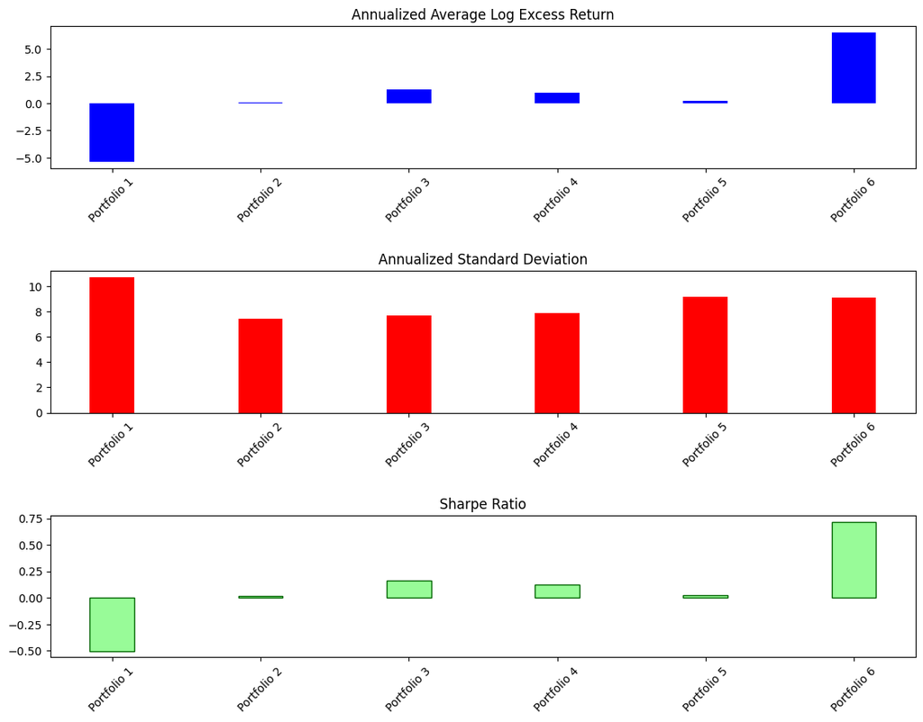

```python
# Create a figure with 3 subplots, one below the other
fig, axs = plt.subplots(3, 1, figsize=(13, 10), gridspec_kw={'height_ratios': [1, 1, 1]})
fig.tight_layout(pad=7.0)  # Add space between plots

# Extract portfolio names for x-axis labels
portfolios = annualize_overall_averages_logex.index

# Annualized Average Log Excess Return Bar Chart
axs[0].bar(portfolios, annualize_overall_averages_logex, color='blue',width=0.3)
axs[0].set_title('Annualized Average Log Excess Return')
axs[0].set_xticks(range(len(portfolios)))
axs[0].set_xticklabels(portfolios, rotation=45)


# Annualized Standard Deviation Bar Chart
axs[1].bar(portfolios, annualize_overall_std_logex, color='red',width=0.3)
axs[1].set_title('Annualized Standard Deviation')
axs[1].set_xticks(range(len(portfolios)))
axs[1].set_xticklabels(portfolios, rotation=45)

# Sharpe Ratio Bar Chart
axs[2].bar(portfolios, sharp_ratio, color='palegreen',edgecolor='darkgreen', linewidth=1,width=0.3)
axs[2].set_title('Sharpe Ratio')
axs[2].set_xticks(portfolios)
axs[2].set_xticklabels(portfolios, rotation=45)

plt.show()
```

### Question B2.2: Compute the difference between the log excess returns of the last and the first portfolio. Is it statistically different from zero

```python
def logex_diff(ptf_shift, df5):
    # Initialize a Series to store the difference for each date
    diff_logex = pd.Series(index=ptf_shift.index)

    for index, row in ptf_shift.iterrows():
        # Assuming each row of ptf_shift contains the asset names for each portfolio
        last_portfolio_assets = row['Portfolio 6']
        first_portfolio_assets = row['Portfolio 1']

        # Directly compute the difference in log excess returns
        # between the last and first portfolios
        last_portfolio_return = df5.loc[index, last_portfolio_assets]
        first_portfolio_return = df5.loc[index, first_portfolio_assets]

        # Calculate the difference and assign it to the diff_logex series
        diff_logex[index] = last_portfolio_return.mean() - first_portfolio_return.mean()

    return diff_logex

# Assuming ptf_shift and df5 are your dataframes
diff_logexcess = logex_diff(ptf_shift, df5)

# Perform a one-sample t-test
t_stat, p_value = stats.ttest_1samp(diff_logexcess.dropna(), 0)

print("T-statistic:", t_stat)
print("p-value:", p_value)

alpha = 0.05  # Set alpha
if p_value < alpha:
    print(f"Difference is statistically significant (p-value: {p_value})")
else:
    print(f"Difference is not statistically significant (p-value: {p_value})")
```

```
T-statistic: 5.5664052414486065
p-value: 5.391059599509187e-08
Difference is statistically significant (p-value: 5.391059599509187e-08)
```

### Construct the carry trade portfolio (i.e. a portfolio which is long the best performing portfolio and short the worst performing portfolio) and compute the average excess return of such a long-short strategy.

```python
#Extract the annual overall average log excess return and choose best and worst portfolios
annualize_overall_averages_logex = pd.Series(annualize_overall_averages_logex)
best_portfolio = annualize_overall_averages_logex.idxmax()
worst_portfolio = annualize_overall_averages_logex.idxmin()

# Compute the average, standard deviation and sharpe ratio of carry trade
averages_logex = averages_logex_date['Portfolio 6'] - averages_logex_date['Portfolio 1']

#The mean
carry_trade_mean = averages_logex.mean()
annual_carry_trade_mean = carry_trade_mean.mean()*12*100 # annual and get percetage

#Standard deviation
carry_trade_std = averages_logex.std()

#Sharp ratio
carry_trade_sharp_ratio = carry_trade_mean/carry_trade_std
annual_carry_trade_sharp_ratio = carry_trade_sharp_ratio*np.sqrt(12)

#Print the results
print("Best Performing Portfolio:", best_portfolio)
print("Worst Performing Portfolio:", worst_portfolio)
print("Average Carry Trade Strategy Return:",annual_carry_trade_mean)
print("Sharpe ratio Carry Trade Strategy:", annual_carry_trade_sharp_ratio)
```

```
Best Performing Portfolio: Portfolio 6
Worst Performing Portfolio: Portfolio 1
Average Carry Trade Strategy Return: 11.87655406481533
Sharpe ratio Carry Trade Strategy: 1.059867186207665
```